# My first CTMC algorithm

My first attempt at fitting a Continous Time Markov Chain (CTMC) to simulated data in a toy problem. Mathematical background on how to build the likelihood can be found in [here](http://www.mathematik.uni-karlsruhe.de/ianm3/~jahnke/media/medijasc2007.pdf).

With all the models in this notebook, I will be simulating data with the Gillespie direct algorithm (see [Gillespie 1977](https://pubs.acs.org/doi/abs/10.1021/j100540a008), or [here](https://en.wikipedia.org/wiki/Gillespie_algorithm) for a simpler explanation), and then inferring the parameters of a CTMC model from the data, using a Bayesian approach and HMC through the software package [Stan](https://mc-stan.org/).

## First toy problem

In this toy problem, we begin with a simple 3 state model, where we follow a single individual, who can be either susceptible (S), depressed (D) or happy (H).

The transitions will be defined as follows:

\begin{align} S \to D & &\text{with rate} & &\beta,\\ D \to H & &\text{with rate} & &\gamma,\\ H \to S & &\text{with rate} & &\omega.\\ \end{align}

To generate the data, I will first define an object for the model, named `ctmc`, with attributes for the `initial` state and the parameters for the CTMC. Within the class, I will also define the functions that will simulate a single `transition` for the chain, and then `simulate` up to a certain time.

```python
class ctmc:
    """Class object to contain the ctmc model"""
    import numpy as np

    def __init__(self,beta, gamma,omega,init):
        self.parameters = (beta,gamma,omega)
        self.initial = init
        self.current = list(init)
        self.totalpop = sum(init)

    def transition(self):
        #First define transition movements

        def depression():
            #being depressed
            self.current[0] -= 1
            self.current[1] += 1

        def recovery():
            #Recovery to happiness
            self.current[1] -=1
            self.current[2] +=1

        def waning():
            #Recovery to happiness
            self.current[2] -=1
            self.current[0] +=1

        #map the functions to the respective index in the transition
        map_transitions = {
            0 : depression,
            1 : recovery,
            2 : waning,
        }

        #Calculate transitions rates
        trans = beta * self.current[0]
        recov = gamma * self.current[1]
        wan  = omega * self.current[2]
        total = trans + recov + wan

        #Record current rates
        self.currentrates = (trans, recov, wan)

        #Draw a transition time
        dt = -1*np.log(np.random.random())/total#np.random.exponential(1/total) #numpy uses scale parameter, inverse of rate

        #Draw a transition
        p = np.array(self.currentrates)/total
        s = np.random.choice(3, p=p)
        map_transitions[s]() #map choice to correct transition function
        #return time to transition and what kind of transition occured
        return dt, s

    def simulate(self,simtime):
        time = 0
        observations = []
        while time < simtime:
            S,D,H = self.current.copy()
            dt, s = self.transition()

            time += dt
            if time > simtime:
                continue
            else:
                #record ctmc state and clock up to the moment of transition
                observations.append((time,dt,s,S,D,H))
        return observations
```

Now that we have the object, let's `simulate` some `data` that we will draw inference from.

```
       time        dt  transition  S  D  R
0  0.000000  0.438339           0  1  0  0
1  0.438339  2.030657           1  0  1  0
2  2.468996  5.341321           2  0  0  1
3  7.810318  0.022213           0  1  0  0
4  7.832530  5.123805           1  0  1  0
We have 50 transitions (data points) in this simulation.
```

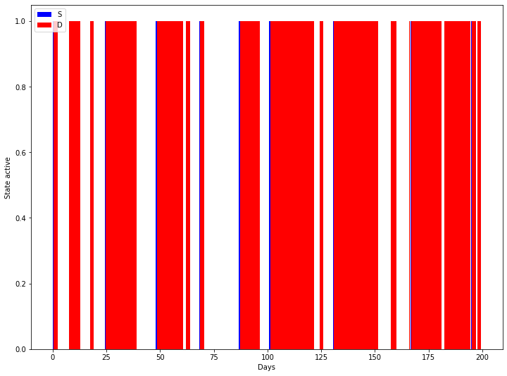

```python
#Simulate a path in the CTMC
import numpy as np
import matplotlib.pyplot as plt
import pandas as pd


init = np.array((1,0,0))
beta = 2
gamma = 0.125
omega = 0.3
nu = 1

toy = ctmc(beta, gamma, omega,init)
obs = toy.simulate(200)

data = pd.DataFrame(obs, columns = ['time','dt','transition','S','D','R'])
data.time = data.time.shift(1).fillna(0)
print(data.head())
print("We have " + format(data.shape[0]) +" transitions (data points) in this simulation.")
fig,ax = plt.subplots(figsize=(12,9))
ax.bar(data.time, data.S, width=data.dt, align='edge', label='S', color='b')
ax.bar(data.time, data.D, width=data.dt, align='edge', label='D', color = 'r')
ax.set_xlabel("Days")
ax.set_ylabel("State active")
plt.legend()
plt.show()
```

The above plot visualises this specific instance of the CTMC, with a solid bar for each duration within each state. With white chunks representing time in the H state. Remember that the CTMC is a random process, defined only by its transitions and states, and this is just one possible instance or path.

With this `data`, now we're going to take only the observed times and the current states to infer the parameters that were used to generate the data. In the next block of code, I construct the Bayesian model in a Stan object, and using the `data` dataframe for inference, draw samples of the posterior for the paramaters $\beta, \gamma$ and $\omega$. We can then compare the distribution of `fit` parameters to our original values.

```python
import pystan

stancode = """
data {
    int<lower=0> N; //length of data
    real<lower=0> dt[N]; //time
    int<lower=0> transitions[N]; //transition code
}
parameters {
    real<lower=0> bet;
    real<lower=0> gamm;
    real<lower=0> omeg;
}
model {
    bet ~ gamma(1.5,1.5); //priors
    gamm ~ gamma(1.5,1.5);
    omeg ~ gamma(1.5,1.5);

    for (n in 1:N){
        if (transitions[n] == 0) {
            //Susceptible to Depressed
            dt[n] ~ exponential(bet);
            }
        else if (transitions[n] == 1) {
            //Depressed to Happy
            dt[n] ~ exponential(gamm);
            }
        else if (transitions[n] == 2) {
            //Happy to Susceptible
            dt[n] ~ exponential(omeg);
        }
    }
}
"""

data_dict = {
    'N': data.shape[0],
    'dt': data['dt'].values,
    'transitions': data.transition.astype(int).values
}

sm = pystan.StanModel(model_code=stancode)
iterations = 1000
chains = 2

fit = sm.sampling(data=data_dict, iter=iterations, chains=chains)
print(fit)
print(toy.parameters)
```

```
INFO:pystan:COMPILING THE C++ CODE FOR MODEL anon_model_2a7a4c6f792505cb2e73917e7953371c NOW.
```

```
Inference for Stan model: anon_model_2a7a4c6f792505cb2e73917e7953371c.
2 chains, each with iter=1000; warmup=500; thin=1;
post-warmup draws per chain=500, total post-warmup draws=1000.

       mean se_mean     sd   2.5%    25%    50%    75%  97.5%  n_eff   Rhat
bet    2.65    0.02   0.62   1.54   2.22   2.61   3.05   4.01    983    1.0
gamm   0.15  1.3e-3   0.03   0.09   0.12   0.14   0.17   0.22    674    1.0
omeg   0.24  1.6e-3   0.05   0.14   0.21   0.24   0.28   0.36   1126    1.0
lp__  -97.9    0.06   1.23 -100.9 -98.47 -97.55 -97.02 -96.56    483   1.01

Samples were drawn using NUTS at Tue Feb  4 14:55:34 2020.
For each parameter, n_eff is a crude measure of effective sample size,
and Rhat is the potential scale reduction factor on split chains (at
convergence, Rhat=1).
(2, 0.125, 0.3)
```

## Simulate a (harder) toy problem

Now let us extend our simple 3 state CTMC model, before going into epidemic specific models.

We will model a single individual suffering from depression again, however, the individual can now also take precautionary measures (i.e. seek help), and move from being susceptible to happy with rate $\nu$.

The transitions will be defined as follows:

\begin{align} S \to D & &\text{with rate} & &\beta,\\ D \to H & &\text{with rate} & &\gamma,\\ H \to S & &\text{with rate} & &\omega,\\ S \to H & &\text{with rate} & &\nu.\\ \end{align}

This time the CTMC is more complex, as when in state S, the chain can jump to either state D or state H. This needs to be accounted for in the likelihood, where a transition out of state S is an exponential clock of all the rates out of S, times the probability the transition ends up at specifically D or H.

For simplicity, we can define the set of parameters to be $\boldsymbol{\theta} = (\beta, \gamma, \omega, \nu)$. For our toy problem, let us set $\boldsymbol{\theta} = ( 2, 0.125, 0.3, 1)$, with an inital start point at S, i.e. $\boldsymbol{n} = (1,0,0)$. Note that our units of time are days.

```python
class ctmc:
    """Class object to contain the ctmc model"""
    import numpy as np

    def __init__(self,beta, gamma, omega, nu,init):
        self.parameters = (beta, gamma, omega,nu)
        assert len(init)==3, "Number of states given is not 3"
        self.initial = init
        self.current = list(init)
        self.totalpop = sum(init)

    def transition(self):
        #First define transition movements

        def depression():
            #being depressed
            self.current[0] -= 1
            self.current[1] += 1

        def recovery():
            #Recovery to happiness
            self.current[1] -=1
            self.current[2] +=1
        def waning():
            #back to susceptible
            self.current[2] -=1
            self.current[0] +=1
        def vacc():
            #susceptible to happy
            self.current[0] -=1
            self.current[2] +=1

        #map the functions to the respective index in the transition
        map_transitions = {
            0 : depression,
            1 : recovery,
            2 : waning,
            3 : vacc,
        }

        #Calculate transitions rates
        trans = beta * self.current[0]
        recov = gamma * self.current[1]
        wane = omega * self.current[2]
        vac = nu * self.current[0]
        total = trans + recov + wane + vac

        #Record current rates
        self.currentrates = (trans, recov, wane, vac)

        #Draw a transition time
        dt = -1*np.log(np.random.random())/total#np.random.exponential(1/total) #numpy uses scale parameter, inverse of rate

        #Draw a transition
        p = np.array(self.currentrates)/total
        s = np.random.choice(4, p=p)
        map_transitions[s]() #map choice to correct transition function
        #return time to transition and what kind of transition occured
        return dt, s

    def simulate(self,simtime):
        time = 0
        observations = []
        while time < simtime:
            S,D,H = self.current.copy()
            dt, s = self.transition()

            time += dt
            if time > simtime:
                continue
            else:

                observations.append((time,dt,s,S,D,H))
        return observations
```

Now that we have our functions and simulation coded, let's run a simulation and observe a possible path for this kind of CTMC. Let's plot the path of the state space over 5,000 days.

```
(1420, 6)
```

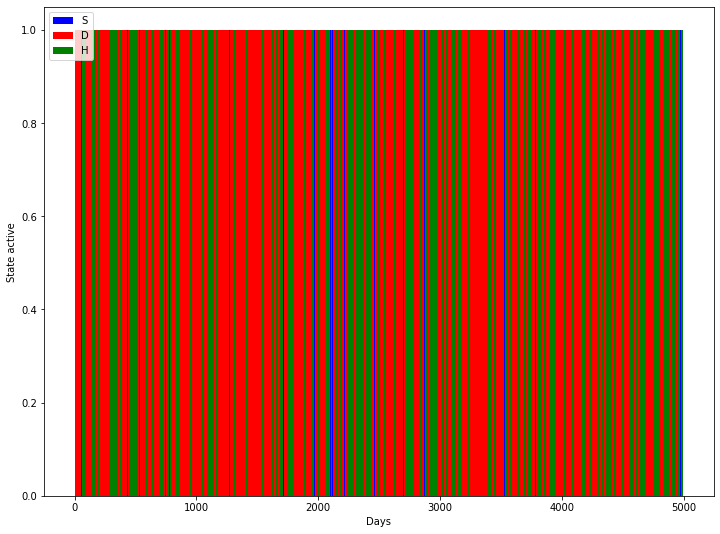

```python
import numpy as np
import matplotlib.pyplot as plt
import pandas as pd


init = np.array((1,0,0))
beta = 2
gamma = 0.125
omega = 0.3
nu = 1

toy = ctmc(beta, gamma, omega,nu, init)
obs = toy.simulate(5000)

data = pd.DataFrame(obs, columns = ['time','dt','transition','S','D','H'])
data.time = data.time.shift(1).fillna(0)
#print(data)
print(data.shape)
fig,ax = plt.subplots(figsize=(12,9))
ax.bar(data.time, data.S, width=data.dt, align='edge', label='S', color='b')
ax.bar(data.time, data.D, width=data.dt, align='edge', label='D', color = 'r')
ax.bar(data.time, data.H, width=data.dt, align='edge', label='H', color='g')
ax.set_xlabel("Days")
ax.set_ylabel("State active")
plt.legend()
plt.show()
```

```python
import pystan

stancode = """
functions {
    real ctmc_lpdf( real dt, real bet, real total) {
        return log(bet) - log(total) + exponential_lpdf( dt | total);
    }
}
data {
    int<lower=0> N; //length of data
    real<lower=0> dt[N]; //time
    int<lower=0> transitions[N]; //transition code
}
parameters {
    real<lower=0> bet;
    real<lower=0> gamm;
    real<lower=0> omega;
    real<lower=0> nu;
}

model {
    bet ~ gamma(1.5,1.5);
    gamm ~ gamma(1.5,1.5);
    omega ~ gamma(1.5,1.5);
    nu ~ gamma(1.5,1.5);

    for (n in 1:N){
        if (transitions[n] == 0) {
            //Susceptible to Depressed
            dt[n] ~ ctmc(bet, bet+nu);
            }
        else if (transitions[n] == 1) {
            //Depressed to Happy
            dt[n] ~ exponential(gamm);
            }
        else if (transitions[n] == 2) {
            //Happy to Susceptible
            dt[n] ~ exponential(omega);
        }
        else if (transitions[n] == 3) {
            //Susceptible to Happy
            dt[n] ~ ctmc(nu, nu+bet);
        }
    }
}
"""

data_dict = {
    'N': data.shape[0],
    'dt': data['dt'].values,
    'transitions': data.transition.astype(int).values
}

sm = pystan.StanModel(model_code=stancode)
iterations = 1000
chains = 2

fit = sm.sampling(data=data_dict, iter=iterations, chains=chains)
print(fit)
print(toy.parameters)
```

```
INFO:pystan:COMPILING THE C++ CODE FOR MODEL anon_model_1fc4828fe1988abf5de967e02af143f1 NOW.
```

```
Inference for Stan model: anon_model_1fc4828fe1988abf5de967e02af143f1.
2 chains, each with iter=1000; warmup=500; thin=1;
post-warmup draws per chain=500, total post-warmup draws=1000.

        mean se_mean     sd   2.5%    25%    50%    75%  97.5%  n_eff   Rhat
bet     2.18  3.5e-3   0.11   1.96    2.1   2.17   2.25    2.4   1077    1.0
gamm    0.12  2.2e-4 6.6e-3   0.11   0.12   0.12   0.13   0.14    935    1.0
omega   0.28  3.6e-4   0.01   0.26   0.27   0.28   0.29    0.3   1100    1.0
nu      0.97  2.7e-3   0.08   0.83   0.92   0.97   1.02   1.13    842    1.0
lp__   -2583    0.06    1.5  -2587  -2584  -2583  -2582  -2581    646    1.0

Samples were drawn using NUTS at Tue Feb  4 14:56:25 2020.
For each parameter, n_eff is a crude measure of effective sample size,
and Rhat is the potential scale reduction factor on split chains (at
convergence, Rhat=1).
(2, 0.125, 0.3, 1)
```

```
WARNING:pystan:Deprecation warning. In future, use ArviZ library (`pip install arviz`)
WARNING:pystan:Deprecation warning. In future, use ArviZ library (`pip install arviz`)
WARNING:pystan:Deprecation warning. In future, use ArviZ library (`pip install arviz`)
WARNING:pystan:Deprecation warning. In future, use ArviZ library (`pip install arviz`)
```

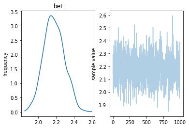

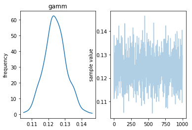

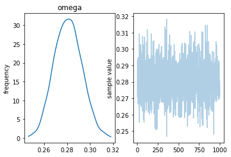

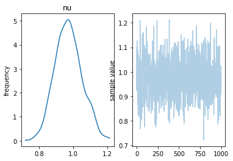

```python
fit.plot(pars=['bet'])
fit.plot(pars=['gamm'])
fit.plot(pars=['omega'])
fit.plot(pars=['nu'])
plt.show()
```

### Maximum Likelihood Estimate

We know from our mathematical source (equation 13) that the Maximum Likelihood Estimate for the rates $r_{i,j}$ are:

\begin{align} \hat{r_{i,j}} & = \frac{N_{i,j}} {\sum dt_{i} }\\ \end{align}

where $N_{i,j}$ is the number of transitions from i to j in the data, and $\sum dt_i$ is the total length of time spent in state i.

```python
##MLE
bet_hat = data.loc[data.transition==0].S.sum()/data.loc[data.S==1].dt.sum()
gamm_hat = data.loc[data.transition==1].D.sum() /data.loc[data.D==1].dt.sum()
omeg_hat = data.loc[data.transition==2].H.sum() / data.loc[data.H==1].dt.sum()
nu_hat = data.loc[data.transition==3].S.sum() /data.loc[data.S==1].dt.sum()
print(bet_hat, gamm_hat, omeg_hat, nu_hat)
print(toy.parameters)
```

```
2.1812218168173647 0.12386175615806391 0.28014523557057047 0.9740798798389876
(2, 0.125, 0.3, 1)
```

## Simulate epidemic problem

First we will simulate some data. We will use a a simple 3 state model, a typical SIRS epidemic model with waning immunity, on a closed population of 100 people. This is similar to our Depression-Happiness model earlier, but now with 100 people, and where the rate of transmission is dependent on the specific number of S and I.

The transitions will be defined as follows:

\begin{align} S \to I & &\text{with rate} & &\beta \frac{SI}{N},\\ I \to R & &\text{with rate} & &\gamma I,\\ R \to S & &\text{with rate} & &\omega R.\\ \end{align}

```python
class sirvs:

    """Class object to contain the ctmc model"""
    import numpy as np

    def __init__(self,beta, gamma, omega, init):
        self.parameters = (beta, gamma, omega)
        assert len(init)==3, "Number of states given is not 3"
        self.initial = init
        self.current = list(init)
        self.totalpop = sum(init)

    def transition(self):
        #First define transition movements
        #0 = S, 1 = I, 2 = R, 3 = V
        def infection():
            #Infected transmission
            self.current[0] -= 1
            self.current[1] += 1

        def recovery():
            #Recovery
            self.current[1] -=1
            self.current[2] +=1
        def waning():
            #waning immunity
            self.current[2] -=1
            self.current[0] +=1
        def vacc():
            #vaccination
            self.current[0] -=1
            self.current[3] +=1

        #map the functions to the respective index in the transition
        map_transitions = {
            0 : infection,
            1 : recovery,
            2 : waning,
            3 : vacc,
        }

        #Calculate transitions rates
        trans = beta * self.current[0]*self.current[1]/self.totalpop
        recov = gamma * self.current[1]
        wane = omega * self.current[2]
        #vac = nu * self.current[1] * self.current[0]/self.totalpop
        total = trans + recov + wane #+ vac

        #Record current rates
        self.currentrates = (trans, recov, wane)

        #Draw a transition time
        dt = -1*np.log(np.random.random())/total#np.random.exponential(1/total) #numpy uses scale parameter, inverse of rate

        #Draw a transition
        p = np.array(self.currentrates)/total
        s = np.random.choice(3, p=p)
        map_transitions[s]() #map choice to correct transition function
        #return time to transition and what kind of transition occured
        return dt, s

    def simulate(self,simtime):
        time = 0
        observations = []
        while time < simtime:
            S,I,R = self.current.copy()
            dt, s = self.transition()

            time += dt
            if time > simtime:
                continue
            else:

                observations.append((time,dt,s,S,I,R))
        return observations
```

Now that we have our functions and simulation coded, let's run a simulation and observe a possible path for this kind of CTMC, or epidemic. Let's see how the state space looks after 100 days.

```
           time        dt  transition  S   I   R
1106  99.782295  0.238649           1  6  37  57
1107  99.789082  0.006787           1  6  36  58
1108  99.791667  0.002585           1  6  35  59
1109  99.933892  0.142226           0  6  34  60
1110  99.990288  0.056396           1  5  35  60
(1111, 6)
```

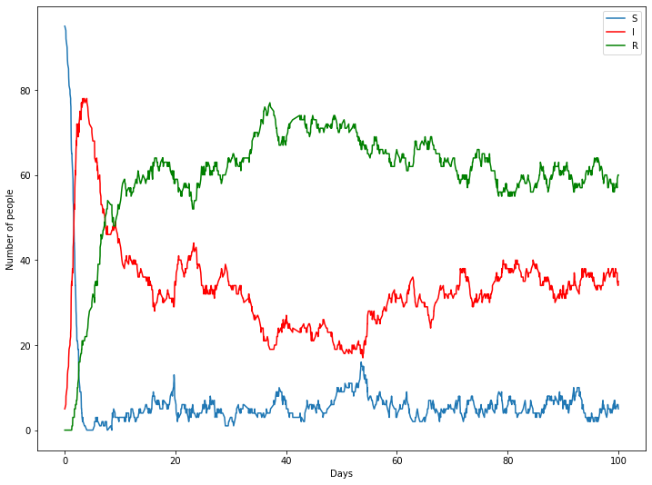

```python
import numpy as np
import matplotlib.pyplot as plt
import pandas as pd


init = np.array((95,5,0))
beta = 2
gamma = 0.125
omega = 1/20

toy = sirvs(beta, gamma, omega, init)
obs = toy.simulate(100)

data2 = pd.DataFrame(obs, columns = ['time','dt','transition','S','I','R'])
print(data2.tail())
print(data2.shape)
fig,ax = plt.subplots(figsize=(12,9))
ax.plot(data2.time, data2.S, label='S')
ax.plot(data2.time, data2.I, label='I', color = 'r')
ax.plot(data2.time, data2.R, label='R', color='g')
ax.set_xlabel("Days")
ax.set_ylabel("Number of people")
plt.legend()
plt.show()
```

Now that we have our data, let's see how we would do inference. As a reminder, the parameters we want to be inferring are $\boldsymbol{\theta} = (\beta, \gamma, \omega)$.

```python
import pystan

stancode = """
functions {
    real ctmc_lpdf( real dt, real bet, real total) {
        return log(bet) - log(total) + exponential_lpdf( dt | total);
    }
}
data {
    int<lower=0> N; //length of data
    int<lower=1> Pop; //total size of population
    real<lower=0> dt[N]; //time
    int<lower=0> Sus[N];
    int<lower=0> I[N];
    int<lower=0> R[N];
    int<lower=0> transitions[N]; //transition code
}
parameters {
    real<lower=0> bet;
    real<lower=0> gamm;
    real<lower=0> omega;
}
model {
    int state;
    real total;
    bet ~ gamma(1,1.5);
    gamm ~ gamma(1,1.5);
    omega ~ gamma(1,1.5);

    for (n in 1:N){
        state = transitions[n];
        total = bet*Sus[n]*I[n] / Pop + gamm*I[n] + omega*R[n];
        if (state == 0) {
            //Infection
            dt[n] ~ ctmc(
            bet*Sus[n]*I[n] / Pop,
            total
            );
            }
        else if (state == 1) {
            //Recovery
            dt[n] ~ ctmc(
                gamm * I[n],
                total
            );
            }
        else if (state == 2) {
            //Waning
            dt[n] ~ ctmc(
                omega * R[n],
                total
            );
            }
    }
}
"""

data_dict = {
    'N': data2.shape[0],
    'Pop': sum(init),
    'dt': data2['dt'].values,
    'Sus': data2.S.values.astype(int),
    'I': data2.I.values.astype(int),
    'R': data2.R.values.astype(int),
    'transitions': data2.transition.astype(int)
}

sm = pystan.StanModel(model_code=stancode)
iterations = 1000
chains = 2

fit = sm.sampling(data=data_dict, iter=iterations, chains=chains)
```

```
INFO:pystan:COMPILING THE C++ CODE FOR MODEL anon_model_3ffd571e602e697a4bdd265537910246 NOW.
```

```
WARNING:pystan:Deprecation warning. In future, use ArviZ library (`pip install arviz`)
```

```
Inference for Stan model: anon_model_3ffd571e602e697a4bdd265537910246.
2 chains, each with iter=1000; warmup=500; thin=1;
post-warmup draws per chain=500, total post-warmup draws=1000.

        mean se_mean     sd   2.5%    25%    50%    75%  97.5%  n_eff   Rhat
bet     2.08  3.2e-3   0.11   1.88   2.01   2.08   2.15    2.3   1104    1.0
gamm    0.11  2.1e-4 6.1e-3    0.1   0.11   0.11   0.12   0.13    861    1.0
omega   0.05  8.8e-5 3.0e-3   0.05   0.05   0.05   0.06   0.06   1137    1.0
lp__   539.0    0.06   1.31 535.62 538.39 539.35 539.96 540.48    508    1.0

Samples were drawn using NUTS at Tue Feb  4 14:57:08 2020.
For each parameter, n_eff is a crude measure of effective sample size,
and Rhat is the potential scale reduction factor on split chains (at
convergence, Rhat=1).
```

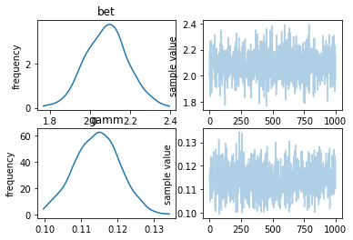

```python
print(fit)
fit.plot(pars=['bet','gamm'])

plt.show()
```